# Séries IMDB - S01E02

Dandara Sousa

26 de maio de 2017

### O Conjunto de Dados

Para essa análise os dados consistem de um conjunto de séries avaliadas no IMDB. Desse conjunto é possível obter informações acerca do nome da série, o nome do episódio, da temporada do episódio, a url onde a avaliação está disponível, a nota do usuário e quão avaliada foi a série de 1 à 10. As séries do conjunto de dados são:

```r
series <- read.csv("../data/series_from_imdb.csv", encoding = "UTF-8" )

unique(series$series_name)
```

```
##   [1] 13 Reasons Why
##   [2] How to Get Away with Murder
##   [3] Mr Robot
##   [4] Sense8
##   [5] Sherlock
##   [6] Are You There
##   [7] Ashes to Ashes
##   [8] Franklin And Bash
##   [9] Monk
##  [10] Mistresses
##  [11] Nikita
##  [12] Roma
##  [13] Tru Calling
##  [14] Happy Town
##  [15] American Dad
```

[output cut: 497 more lines]

Primeiro, observando o conjunto, surge o interesse em saber se séries mais antigas são mais bem avaliadas que as mais novas.Ou seja, se as séries clássicas são vistas como melhores diante o público. Para isso, toma-se como base que séries mais antigas possuem mais temporadas que as mais atuais e, assim, é possível avaliar a avaliação das séries extremas (as com menos temporadas e as com mais). Primeiro, é necessário encontrar as séries que serão comparadas.

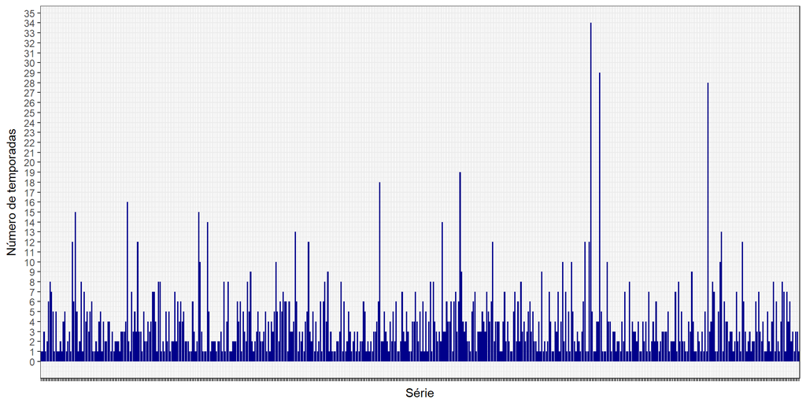

```r
series %>%
  group_by(series_name) %>%
  summarise(numeroTemp = max(season)) %>%
  ggplot(aes(x = series_name, y = numeroTemp)) +
  geom_bar(stat = "identity", fill = "dark blue") +
  theme(axis.text.x = element_blank()) +
  labs(x="Série",y="Número de temporadas") +
  scale_y_continuous(breaks=seq(0, 45, 1))
```

A partir do gráfico de barras é difícil visualizar as séries para escolher. Porém, pelo gosto da autora serão escolhidas 13 Reasons Why e Stranger Things com uma temporada cada e The Simpsons com vinte e oito temporadas. Agora, um meio para a comparar visualmente as avaliações é através de um boxplot que permite observar a distribuição de notas (que foi facilitada através de pontos no gráfico) e a mediana. Utilizar mediana é melhor que a média nesse caso, uma vez que notas extremas afetariam diretamente a média e isto não ocorre com o cálculo da mediana.

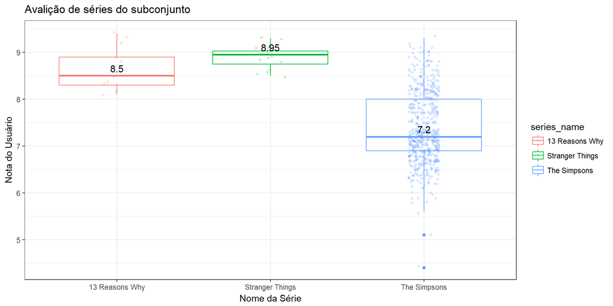

```r
series_extremas = series %>% filter(series_name %in% c("13 Reasons Why","Stranger Things","The Simpsons"))
series_extremas %>%
  ggplot(aes(x = series_name,y = UserRating, color = series_name)) +
  geom_boxplot() +
  labs(title = "Avalição de séries do subconjunto", x= "Nome da Série", y= "Nota do Usuário") +
  geom_jitter(width = .1, size = 1, alpha = .2) +
  stat_summary(aes(label=round(..y..,2)), fun.y=median, geom="text", size=4, vjust = -0.5, color = "black") +
  scale_y_continuous(breaks=seq(0, 10, 1))
```

A partir do gráfico é possível visualizar que as séries mais recentes possuem uma avaliação geral maior que as antigas. Mas também abre espaço para o questionamento de que a mediana geral de uma série com apenas uma temporada inclui muito menos parâmetro de que uma série com mais temporadas e isso influenciaria a resposta final. Então, analisando a mediana apenas da primeira temporada de todas as séries do subconjunto, temos:

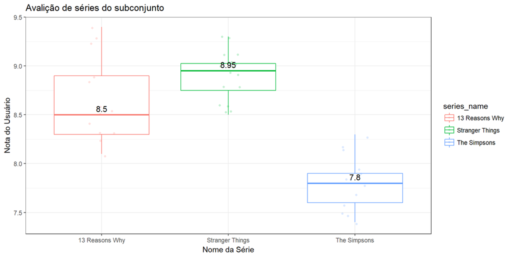

```r
series_extremas_season1 = series_extremas %>% filter(season == 1)
series_extremas_season1 %>%
  ggplot(aes(x = series_name,y = UserRating, color = series_name)) +
  geom_boxplot() +
  labs(title = "Avalição de séries do subconjunto", x= "Nome da Série", y= "Nota do Usuário") +
  geom_jitter(width = .1, size = 1, alpha = .2) +
  stat_summary(aes(label=round(..y..,2)), fun.y=median, geom="text", size=4, vjust = -0.5, color = "black") +
  scale_y_continuous(breaks=seq(5, 10, .5))
```

A partir desse segundo gráfico é possível notar que as mudanças que acontecem são que a mediana de The Simpsons cresceu mas não de forma tão notável e significativa, além de quê há bem menos concentração de pontos abaixo do boxplot de The Simpsons quando considerada apenas a primeira temporada. Ainda assim, nesse conjunto de dados, as medianas das primeiras temporadas das séries se assemelham com a mediana geral e no fim isso reforça que as séries mais novas são melhores avaliadas que as antigas.

Outra curiosidade que vem a surgir é saber se as notas das séries crescem de acordo com as temporadas, indicando para as produtoras que a série está fazendo sucesso e isso justificaria porque algumas séries são mais longas que outras. E daí também pode ser questionado se séries com avaliação decaindo a cada temporada são rapidamente canceladas. Para facilitar o entendimento foram feitos dois gráficos: o primeiro possui as séries que possuem até quatro temporadas e o segundo as de mais de quatro temporadas. Também foi considerado aqui o uso da mediana pelos mesmo motivos já citados nos questionamentos anteriores.

```r
series_por_temporada <- series %>%
  group_by(series_name) %>% summarise(n_temporadas = max(season))
series <- merge(x = series, y = series_por_temporada, by = "series_name", all.x = TRUE)

series_recentes <- series %>%
  filter(n_temporadas < 5)
series_antigas <- series %>%
  filter(n_temporadas >= 5)
nrow(unique(series_recentes["series_name"]))
```

```
## [1] 360
```

```r
nrow(unique(series_antigas["series_name"]))
```

```
## [1] 151
```

Pelo alto número de séries, vamos novamente selecionar apenas algumas para prosseguir na rápida análise.

```r
series_recentes = series %>% filter(series_name %in% c("13 Reasons Why","Agents of S.H.I.E.L.D.","Black Mirror","Daredevil","Flash","Gotham","House of Cards","How to Get Away with Murder","Mr Robot", "Narcos", "Orphan Black", "Prison Break","Sense8","Sherlock","Stranger Things","The 100", "The Blacklist","Vikings"))
series_antigas = series %>% filter(series_name %in% c("Arrow","Breaking Bad","Dexter","Friends","Game of Thrones","Grey's Anatomy","Homeland","How I Met Your Mother","Modern Family","Once Upon a Time","Scandal","Supernatural","The Simpsons","The Walking Dead"))
```

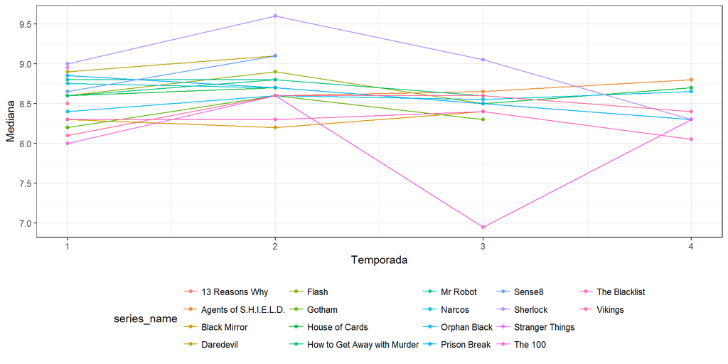

```r
series_recentes %>%
  group_by(series_name,season) %>%
  summarise(mediana = median(UserRating)) %>%
  ggplot(aes(x = season,y = mediana, color = series_name)) +
  geom_point(alpha=.8) +
  geom_line() +
  scale_x_continuous(breaks=seq(0, 11, 1)) +
  scale_y_continuous(breaks=seq(6, 10, .5)) +
  theme(legend.position = "bottom") +
  labs(x = "Temporada",y = "Mediana")
```

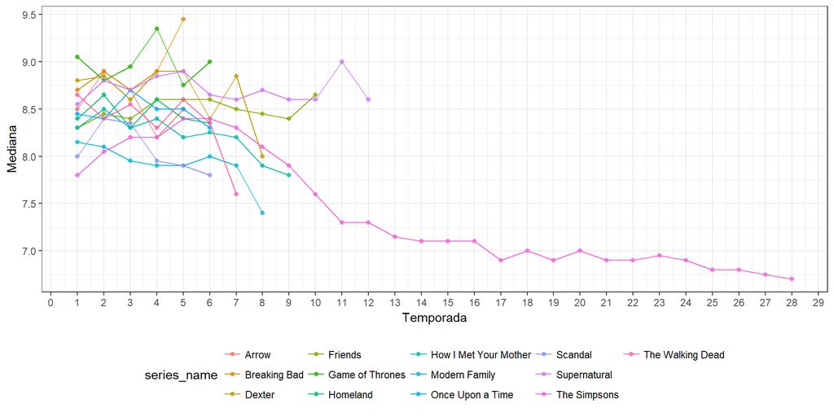

```r
series_antigas %>%
  group_by(series_name,season) %>%
  summarise(mediana = median(UserRating)) %>%
  ggplot(aes(x = season,y = mediana, color = series_name)) +
  geom_point(alpha=.8) +
  geom_line() +
  scale_x_continuous(breaks=seq(0, 30, 1)) +
  scale_y_continuous(breaks=seq(6, 10, .5)) +
  theme(legend.position = "bottom") +
  labs(x = "Temporada",y = "Mediana")
```